# Data606Homework2

Stephanie Roark

9/22/2018

## Probability

### 2.6 Dice rolls. If you roll a pair of fair dice, what is the probability of

1. getting a sum of 1? A sum less than 2 is not possible as the dice are from 1-6 each. 0/36 X 1/36 = 0
2. getting a sum of 5? There are 4 ways to get a sum of 5: 1,4; 2,3; 3,2; 4,1 (1/6 x 1/6) + (1/6 x 1/6) + (1/6 x 1/6) + (1/6 x 1/6) = 4/36
3. getting a sum of 12? There is only one combination that gives 2 6’s. 1/6 x 1/6 = 1/36

### 2.8 Poverty and language. The American Community Survey is an ongoing survey that provides data every year to give communities the current information they need to plan investments and services. The 2010 American Community Survey estimates that 14.6% of Americans live below the poverty line, 20.7% speak a language other than English (foreign language) at home, and 4.2% fall into both categories.

1. Are living below the poverty line and speaking a foreign language at home disjoint?

Disjoint would mean that there is no overlap between the 2 groups and we know that 4.2% of those surveyed fall into both categories. Therefore the variables are not disjoint.

2. Draw a Venn diagram summarizing the variables and their associated probabilities.

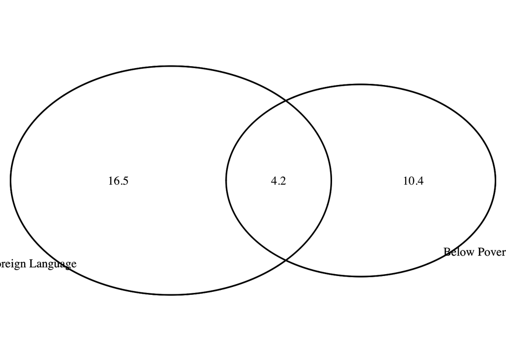

```r
library(VennDiagram)
venn.plot <- draw.pairwise.venn(14.6, 20.7, 4.2, c("Below Poverty", "Foreign Language"));
grid.draw(venn.plot)
```

3. What percent of Americans live below the poverty line and only speak English at home?

The Venn Diagram shows that 14.6% - 4.2% = 10.4% of Americans live below the poverty line and only speak English at home.

4. What percent of Americans live below the poverty line or speak a foreign language at home?

5. What percent of Americans live above the poverty line and only speak English at home?

Percentage who live above poverty line and only speak English at home =

```r
100 - 10.4 - 20.7
```

```
## [1] 68.9
```

6. Is the event that someone lives below the poverty line independent of the event that the person speaks a foreign language at home?

P(lives below pov line & speaks foreign lang) = P(pl) X P(fl) =

```r
.207 * .146 *100
```

```
## [1] 3.0222
```

P(lives below pl and speaks fl) = 4.2%

The probabilities are not equal and therefore the events are not independent.

### 2.20 Assortative mating. Assortative mating is a nonrandom mating pattern where individuals with similar genotypes and/or phenotypes mate with one another more frequently than what would be expected under a random mating pattern. Researchers studying this topic collected data on eye colors of 204 Scandinavian men and their female partners. The table below summarizes the results. For simplicity, we only include heterosexual relationships in this exercise.

```
                Partner (female)
                Blue Brown Green Total
             Blue 78 23 13 114
 Self (male)Brown 19 23 12 54
            Green 11 9 16 36
            Total 108 55 41 204
```

1. What is the probability that a randomly chosen male respondent or his partner has blue eyes?

```r
(78 + 23 + 13 + 19 + 11)/204
```

```
## [1] 0.7058824
```

2. What is the probability that a randomly chosen male respondent with blue eyes has a partner with blue eyes?

```r
78/114
```

```
## [1] 0.6842105
```

3. What is the probability that a randomly chosen male respondent with brown eyes has a partner with blue eyes?

```r
19/54
```

```
## [1] 0.3518519
```

What about the probability of a randomly chosen male respondent with green eyes having a partner with blue eyes?

```r
11/36
```

```
## [1] 0.3055556
```

4. Does it appear that the eye colors of male respondents and their partners are independent? Explain your reasoning.

Eye color is not independent in choosing a partner

### 2.30 Books on a bookshelf. The table below shows the distribution of books on a bookcase based on whether they are nonfiction or fiction and hardcover or paperback.

```
            Format
            Hardcover Paperback Total
    Type Fiction 13 59 72
      Nonfiction 15 8 23
           Total 28 67 95
```

1. Find the probability of drawing a hardcover book first then a paperback fiction book second when drawing without replacement.

```r
28/95 * 59/94
```

```
## [1] 0.1849944
```

2. Determine the probability of drawing a fiction book first and then a hardcover book second, when drawing without replacement.

```r
13/95 * 27/94 + 59/95 * 28/94
```

```
## [1] 0.2243001
```

3. Calculate the probability of the scenario in part (b), except this time complete the calculations under the scenario where the first book is placed back on the bookcase before randomly drawing the second book.

```r
72/95 * 28/95
```

```
## [1] 0.2233795
```

4. The final answers to parts (b) and (c) are very similar. Explain why this is the case.

Replacing the book allows for the possibility that it could be chosen as a hardback in the second draw, however it only slightly alters the total books that can be drawn from and does not change the probability significantly.

### 2.38 Baggage fees. An airline charges the following baggage fees: $25 for the first bag and $35 for the second. Suppose 54% of passengers have no checked luggage, 34% have one piece of checked luggage and 12% have two pieces. We suppose a negligible portion of people check more than two bags.

1. Build a probability model, compute the average revenue per passenger, and compute the corresponding standard deviation.

Average revenue per passenger =

```r
0*.54 + 25*.34 + 35*.12
```

```
## [1] 12.7
```

Standard deviation =

```r
((0- 12.7)**2 *.54+ (25 - 12.7)**2*.34 + (35-12.7)**2*.12)**.5
```

```
## [1] 14.07871
```

2. About how much revenue should the airline expect for a flight of 120 passengers?

```r
(0*.54 + 25*.34 + 35*.12)*120
```

```
## [1] 1524
```

With what standard deviation? Note any assumptions you make and if you think they are justified.

### 2.44 Income and gender. The relative frequency table below displays the distribution of annual total personal income (in 2009 inflation-adjusted dollars) for a representative sample of 96,420,486 Americans. These data come from the American Community Survey for 2005-2009. This sample is comprised of 59% males and 41% females.

```
            Income               Total
            $1 to $9,999 or loss 2.2%
            $10,000 to $14,999 4.7%
            $15,000 to $24,999 15.8%
            $25,000 to $34,999 18.3%
            $35,000 to $49,999 21.2%
            $50,000 to $64,999 13.9%
            $65,000 to $74,999 5.8%
            $75,000 to $99,999 8.4%
            $100,000 or more 9.7%
```

1. Describe the distribution of total personal income.

The distrubution is fairly symmetric around the $35,000 to $49,999 range with a longer right skewed tail.

2. What is the probability that a randomly chosen US resident makes less than $50,000 per year?

```r
(.022 + .047 + .158 + .183 + .212)
```

```
## [1] 0.622
```

3. What is the probability that a randomly chosen US resident makes less than $50,000 per year and is female? Note any assumptions you make.

Assumption: females are evenly distributed throughout the income distribution and the sample represents the US population.

```r
(.022 + .047 + .158 + .183 + .212)*.41
```

```
## [1] 0.25502
```

4. The same data source indicates that 71.8% of females make less than $50,000 per year. Use this value to determine whether or not the assumption you made in part (c) is valid

From the previous example, the probability of a randomly chosen person making less than $50,000 and who is female is is 25.5%. So the number of females making less than $50k is:

```r
96420486 * .255
```

```
## [1] 24587224
```

If the same data source says that 71.8% of females make less than $50,000 per year then:

```r
(96420486 * .718)
```

```
## [1] 69229909
```

The assumption that women are evenly distributed throughout the income distribution or that the sample represents the US population is incorrect.